# **Introduction to Open Data Science, Exercise Set 5**

Dimensionality reduction techniques

This set consists of a few numbered exercises. Go to each exercise in turn and do as follows:

1. Read the brief description of the exercise.
2. Run the (possible) pre-exercise-code chunk.
3. Follow the instructions to fix the R code!

## 5.0 INSTALL THE REQUIRED PACKAGES FIRST!

One or more extra packages (in addition to `tidyverse`) will be needed below.

```r
# Select (with mouse or arrow keys) the install.packages("...") and
# run it (by Ctrl+Enter / Cmd+Enter):

# install.packages("FactoMineR")
```

## 5.1 Meet the human data

We will be using the `human` dataset to introduce Principal Components Analysis (PCA). The data originates from the United Nations Development Programme. See [their data page](https://hdr.undp.org/data-center/human-development-index) for more information. For a nice overview see also the [calculating the human development indices pdf](https://hdr.undp.org/system/files/documents//technical-notes-calculating-human-development-indices.pdf).

Most of the variable names have been shortened and two new variables have been computed. See the meta file for the modified data [here](https://github.com/KimmoVehkalahti/Helsinki-Open-Data-Science/blob/master/datasets/human_meta.txt) for descriptions.

### Instructions

- Read the `human` data into memory
- Print out the (column) names of the data
- Look at the structure of the data
- Print out summaries of the variables in the data

Hints: - Use `str()` to see structure - Use `summary()` to compute summaries

### R code

```r
# This is a code chunk in RStudio editor.

library(readr)
# read the human data
human <- read_csv("https://raw.githubusercontent.com/KimmoVehkalahti/Helsinki-Open-Data-Science/master/datasets/human1.csv")
# look at the (column) names of human
names(human)
```

```
##  [1] "HDI.Rank"       "Country"        "HDI"            "Life.Exp"
##  [5] "Edu.Exp"        "Edu.Mean"       "GNI"            "GNI.Minus.Rank"
##  [9] "GII.Rank"       "GII"            "Mat.Mor"        "Ado.Birth"
## [13] "Parli.F"        "Edu2.F"         "Edu2.M"         "Labo.F"
## [17] "Labo.M"         "Edu2.FM"        "Labo.FM"
```

```r
# look at the structure of human
str(human)
```

```
## spc_tbl_ [195 × 19] (S3: spec_tbl_df/tbl_df/tbl/data.frame)
##  $ HDI.Rank      : num [1:195] 1 2 3 4 5 6 6 8 9 9 ...
##  $ Country       : chr [1:195] "Norway" "Australia" "Switzerland" "Denmark" ...
##  $ HDI           : num [1:195] 0.944 0.935 0.93 0.923 0.922 0.916 0.916 0.915 0.913 0.913 ...
##  $ Life.Exp      : num [1:195] 81.6 82.4 83 80.2 81.6 80.9 80.9 79.1 82 81.8 ...
##  $ Edu.Exp       : num [1:195] 17.5 20.2 15.8 18.7 17.9 16.5 18.6 16.5 15.9 19.2 ...
##  $ Edu.Mean      : num [1:195] 12.6 13 12.8 12.7 11.9 13.1 12.2 12.9 13 12.5 ...
##  $ GNI           : num [1:195] 64992 42261 56431 44025 45435 ...
##  $ GNI.Minus.Rank: num [1:195] 5 17 6 11 9 11 16 3 11 23 ...
##  $ GII.Rank      : num [1:195] 1 2 3 4 5 6 6 8 9 9 ...
##  $ GII           : num [1:195] 0.067 0.11 0.028 0.048 0.062 0.041 0.113 0.28 0.129 0.157 ...
##  $ Mat.Mor       : num [1:195] 4 6 6 5 6 7 9 28 11 8 ...
##  $ Ado.Birth     : num [1:195] 7.8 12.1 1.9 5.1 6.2 3.8 8.2 31 14.5 25.3 ...
##  $ Parli.F       : num [1:195] 39.6 30.5 28.5 38 36.9 36.9 19.9 19.4 28.2 31.4 ...
##  $ Edu2.F        : num [1:195] 97.4 94.3 95 95.5 87.7 96.3 80.5 95.1 100 95 ...
##  $ Edu2.M        : num [1:195] 96.7 94.6 96.6 96.6 90.5 97 78.6 94.8 100 95.3 ...
##  $ Labo.F        : num [1:195] 61.2 58.8 61.8 58.7 58.5 53.6 53.1 56.3 61.6 62 ...
##  $ Labo.M        : num [1:195] 68.7 71.8 74.9 66.4 70.6 66.4 68.1 68.9 71 73.8 ...
##  $ Edu2.FM       : num [1:195] 1.007 0.997 0.983 0.989 0.969 ...
##  $ Labo.FM       : num [1:195] 0.891 0.819 0.825 0.884 0.829 ...
##  - attr(*, "spec")=
##   .. cols(
##   ..   HDI.Rank = col_double(),
##   ..   Country = col_character(),
##   ..   HDI = col_double(),
##   ..   Life.Exp = col_double(),
##   ..   Edu.Exp = col_double(),
##   ..   Edu.Mean = col_double(),
##   ..   GNI = col_double(),
##   ..   GNI.Minus.Rank = col_double(),
##   ..   GII.Rank = col_double(),
##   ..   GII = col_double(),
##   ..   Mat.Mor = col_double(),
##   ..   Ado.Birth = col_double(),
##   ..   Parli.F = col_double(),
##   ..   Edu2.F = col_double(),
##   ..   Edu2.M = col_double(),
##   ..   Labo.F = col_double(),
##   ..   Labo.M = col_double(),
##   ..   Edu2.FM = col_double(),
##   ..   Labo.FM = col_double()
##   .. )
##  - attr(*, "problems")=<externalptr>
```

```r
# print out summaries of the variables
summary(human)
```

```
##     HDI.Rank        Country               HDI            Life.Exp
##  Min.   :  1.00   Length:195         Min.   :0.3480   Min.   :49.00
##  1st Qu.: 47.75   Class :character   1st Qu.:0.5770   1st Qu.:65.75
##  Median : 94.00   Mode  :character   Median :0.7210   Median :73.10
##  Mean   : 94.31                      Mean   :0.6918   Mean   :71.07
##  3rd Qu.:141.25                      3rd Qu.:0.8000   3rd Qu.:76.80
##  Max.   :188.00                      Max.   :0.9440   Max.   :84.00
##  NA's   :7
##     Edu.Exp         Edu.Mean           GNI         GNI.Minus.Rank
##  Min.   : 4.10   Min.   : 1.400   Min.   :   581   Min.   :-84.0000
##  1st Qu.:11.10   1st Qu.: 5.550   1st Qu.:  3772   1st Qu.: -9.0000
##  Median :13.10   Median : 8.400   Median : 10939   Median :  1.5000
##  Mean   :12.86   Mean   : 8.079   Mean   : 16801   Mean   :  0.1862
##  3rd Qu.:14.90   3rd Qu.:10.600   3rd Qu.: 22316   3rd Qu.: 11.0000
##  Max.   :20.20   Max.   :13.100   Max.   :123124   Max.   : 47.0000
##                                                    NA's   :7
##     GII.Rank           GII            Mat.Mor         Ado.Birth
##  Min.   :  1.00   Min.   :0.0160   Min.   :   1.0   Min.   :  0.60
##  1st Qu.: 47.75   1st Qu.:0.2030   1st Qu.:  16.0   1st Qu.: 15.45
##  Median : 94.00   Median :0.3935   Median :  69.0   Median : 40.95
##  Mean   : 94.31   Mean   :0.3695   Mean   : 163.2   Mean   : 49.55
##  3rd Qu.:141.25   3rd Qu.:0.5272   3rd Qu.: 230.0   3rd Qu.: 71.78
##  Max.   :188.00   Max.   :0.7440   Max.   :1100.0   Max.   :204.80
##  NA's   :7        NA's   :33       NA's   :10       NA's   :5
##     Parli.F          Edu2.F          Edu2.M           Labo.F
##  Min.   : 0.00   Min.   :  0.9   Min.   :  3.20   Min.   :13.50
##  1st Qu.:12.47   1st Qu.: 27.8   1st Qu.: 38.30   1st Qu.:44.50
##  Median :19.50   Median : 55.7   Median : 60.00   Median :53.30
##  Mean   :20.60   Mean   : 54.8   Mean   : 60.29   Mean   :52.61
##  3rd Qu.:27.02   3rd Qu.: 81.8   3rd Qu.: 85.80   3rd Qu.:62.62
##  Max.   :57.50   Max.   :100.0   Max.   :100.00   Max.   :88.10
##  NA's   :3       NA's   :26      NA's   :26       NA's   :11
##      Labo.M         Edu2.FM          Labo.FM
##  Min.   :44.20   Min.   :0.1717   Min.   :0.1857
##  1st Qu.:68.88   1st Qu.:0.7284   1st Qu.:0.5987
##  Median :75.55   Median :0.9349   Median :0.7514
##  Mean   :74.74   Mean   :0.8541   Mean   :0.7038
##  3rd Qu.:80.15   3rd Qu.:0.9968   3rd Qu.:0.8513
##  Max.   :95.50   Max.   :1.4967   Max.   :1.0380
##  NA's   :11      NA's   :26       NA's   :11
```

## 5.2 String manipulation

(Exercise 5.2 has been removed. Just move on!)

## 5.3 Dealing with not available (NA) values

In R, NA stands for not available, which means that the data point is missing. If a variable you wish to analyse contains missing values, there are usually two main options:

- Remove the observations with missing values
- Replace the missing values with actual values using an *imputation* technique.

We will use the first option, which is the simplest solution.

### Instructions

- Create a smaller version of the human data by selecting the variables defined in `keep`
- Use complete.cases() on human to print out a logical “completeness indicator” vector
- Adjust the code: Define `comp` as the completeness indicator and print out the resulting data frame. When is the indicator `FALSE` and when is it `TRUE`? (hint: `?complete.cases()`).
- `filter()` out all the rows with any `NA` values. Right now, `TRUE` is recycled so that nothing is filtered out.

Hints: - Use `complete.cases()` on ‘human’ again to define the ‘comp’ column - Use the logical vector created by complete.cases to filter out the rows with `NA` values.

### R code

```r
# Work with the exercise in this chunk, step-by-step. Fix the R code!
# human with modified GNI is available

library(dplyr)
# columns to keep
keep <- c("Country", "Edu2.FM", "Labo.FM", "Life.Exp", "Edu.Exp", "GNI", "Mat.Mor", "Ado.Birth", "Parli.F")

# select the 'keep' columns
human <- select(human, one_of(keep))

# print out a completeness indicator of the 'human' data
complete.cases(human)
```

```
##   [1]  TRUE  TRUE  TRUE  TRUE  TRUE  TRUE  TRUE  TRUE  TRUE  TRUE  TRUE FALSE
##  [13] FALSE  TRUE  TRUE  TRUE  TRUE  TRUE  TRUE  TRUE  TRUE  TRUE  TRUE  TRUE
##  [25]  TRUE  TRUE  TRUE  TRUE  TRUE  TRUE FALSE  TRUE  TRUE FALSE  TRUE  TRUE
##  [37]  TRUE  TRUE  TRUE  TRUE  TRUE  TRUE  TRUE  TRUE  TRUE  TRUE  TRUE  TRUE
##  [49]  TRUE  TRUE  TRUE  TRUE  TRUE  TRUE  TRUE  TRUE  TRUE FALSE  TRUE FALSE
##  [61]  TRUE  TRUE  TRUE FALSE  TRUE  TRUE  TRUE  TRUE  TRUE  TRUE  TRUE  TRUE
##  [73]  TRUE  TRUE  TRUE  TRUE FALSE  TRUE FALSE  TRUE  TRUE  TRUE  TRUE  TRUE
##  [85]  TRUE  TRUE  TRUE  TRUE FALSE  TRUE  TRUE  TRUE  TRUE FALSE  TRUE  TRUE
##  [97]  TRUE FALSE  TRUE  TRUE  TRUE  TRUE  TRUE  TRUE  TRUE  TRUE  TRUE  TRUE
## [109] FALSE  TRUE  TRUE  TRUE FALSE FALSE  TRUE  TRUE  TRUE  TRUE  TRUE  TRUE
## [121]  TRUE FALSE FALSE  TRUE  TRUE  TRUE  TRUE  TRUE  TRUE  TRUE  TRUE  TRUE
## [133] FALSE  TRUE FALSE  TRUE FALSE FALSE  TRUE  TRUE FALSE  TRUE  TRUE FALSE
## [145]  TRUE  TRUE  TRUE  TRUE FALSE  TRUE  TRUE FALSE  TRUE FALSE  TRUE  TRUE
## [157] FALSE  TRUE FALSE  TRUE  TRUE  TRUE  TRUE  TRUE  TRUE  TRUE  TRUE FALSE
## [169] FALSE  TRUE  TRUE  TRUE  TRUE  TRUE  TRUE  TRUE  TRUE FALSE  TRUE  TRUE
## [181]  TRUE FALSE  TRUE  TRUE  TRUE FALSE  TRUE  TRUE  TRUE  TRUE  TRUE  TRUE
## [193]  TRUE  TRUE  TRUE
```

```r
# print out the data along with a completeness indicator as the last column
data.frame(human[-1], comp = complete.cases(human))
```

```
##       Edu2.FM   Labo.FM Life.Exp Edu.Exp    GNI Mat.Mor Ado.Birth Parli.F  comp
## 1   1.0072389 0.8908297     81.6    17.5  64992       4       7.8    39.6  TRUE
## 2   0.9968288 0.8189415     82.4    20.2  42261       6      12.1    30.5  TRUE
## 3   0.9834369 0.8251001     83.0    15.8  56431       6       1.9    28.5  TRUE
## 4   0.9886128 0.8840361     80.2    18.7  44025       5       5.1    38.0  TRUE
## 5   0.9690608 0.8286119     81.6    17.9  45435       6       6.2    36.9  TRUE
## 6   0.9927835 0.8072289     80.9    16.5  43919       7       3.8    36.9  TRUE
## 7   1.0241730 0.7797357     80.9    18.6  39568       9       8.2    19.9  TRUE
## 8   1.0031646 0.8171263     79.1    16.5  52947      28      31.0    19.4  TRUE
## 9   1.0000000 0.8676056     82.0    15.9  42155      11      14.5    28.2  TRUE
## 10  0.9968520 0.8401084     81.8    19.2  32689       8      25.3    31.4  TRUE
## 11  0.9148148 0.7616580     83.0    15.4  76628       6       6.0    25.3  TRUE
## 12  0.9116162 0.7566372     84.0    15.6  53959      NA       3.3      NA FALSE
## 13         NA        NA     80.0    15.0  79851      NA        NA    20.0 FALSE
## 14  0.9908362 0.8880707     82.2    15.8  45636       4       6.5    43.6  TRUE
```

[output cut: 181 more lines]

```r
# filter out all rows with NA values
human_ <- filter(human, complete.cases(human)) # modify the "TRUE", see instructions above!
```

## 5.4 Excluding observations

Besides missing values, there might be other reasons to exclude observations. In our human data, there are a few data points which have been computed from other observations. We want to remove them before further analysis.

The basic way in R to reference the rows or columns of a data frame is to use brackets (`[,]`) along with indices or names. A comma is used to separate row and column references.

In the schematic examples below, `df` refers to a data frame:

```
df[,] # select every row and every column
df[1:5, ] # select first five rows
df[, c(2, 5)] # select 2nd and 5th columns
```

### Instructions

Hint: - Use `1:last` to select rows from 1 to `last`

### R code

```r
# Work with the exercise in this chunk, step-by-step. Fix the R code!
# human without NA is available

# look at the last 10 observations of human
tail(human)
```

```
## # A tibble: 6 × 9
##   Country       Edu2.FM Labo.FM Life.Exp Edu.Exp   GNI Mat.Mor Ado.Birth Parli.F
##   <chr>           <dbl>   <dbl>    <dbl>   <dbl> <dbl>   <dbl>     <dbl>   <dbl>
## 1 East Asia an…   0.825   0.788     74      12.7 11449      72      21.2    18.7
## 2 Europe and C…   0.878   0.651     72.3    13.6 12791      28      30.8    19
## 3 Latin Americ…   0.984   0.673     75      14   14242      85      68.3    27
## 4 South Asia      0.533   0.371     68.4    11.2  5605     183      38.7    17.5
## 5 Sub-Saharan …   0.702   0.854     58.5     9.6  3363     506     110.     22.5
## 6 World           0.833   0.656     71.5    12.2 14301     210      47.4    21.8
```

```r
# define the last indice we want to keep
last <- nrow(human) - 7

# choose everything until the last 7 observations
human_ <- human[1:last, ]
```

## 5.5 Exploring the countries

Now that we have sufficiently wrangled the ‘human’ data for further analysis, let’s explore the variables and their relationships more closely.

A simple pairs plot or a more informative generalized pairs plot from the **GGally** package is a good way of visualizing a reasonably sized data frame.

To study linear connections, correlations also can be computed with the `cor()` function and then visualized with the corrplot function from the **corrplot** package.

### Instructions

- Create the data frame `human_` so that the country names (from the `Country` variable of the `human` data) become rownames
- Access the GGally package and visualize all the `human_` variables with `ggpairs()` (you may use the argument `progress = FALSE` to suppress the quite unnecessary plotting progress indicators)
- Compute and print out the correlation matrix of `human_`
- Adjust the code: use the pipe operator (`%>%`) and visualize the correlation matrix with `corrplot()`.

Hint: - The pipe assigns the output on its left as the first argument to the function name on its right. Use it on the same line where the correlation matrix is computed

### R code

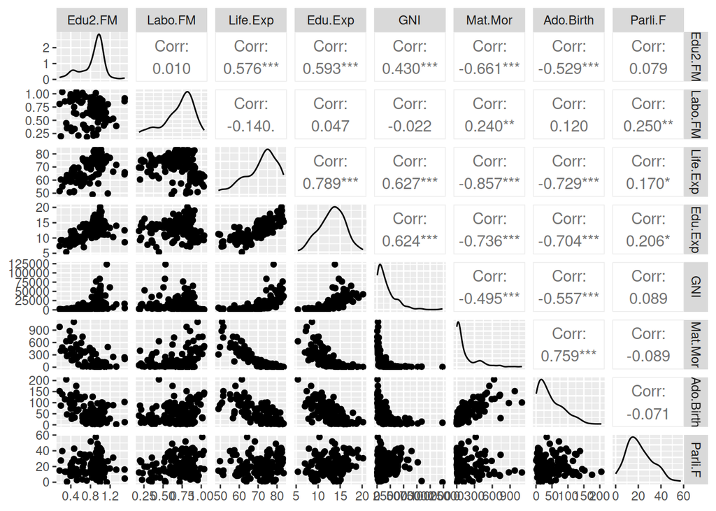

```r
# Work with the exercise in this chunk, step-by-step. Fix the R code!
# modified human, dplyr and the corrplot functions are available

# move the country names to rownames
library(tibble)
human_ <- column_to_rownames(human, "Country")

# Access GGally
library(GGally)
# visualize the 'human_' variables
ggpairs(human_)
```

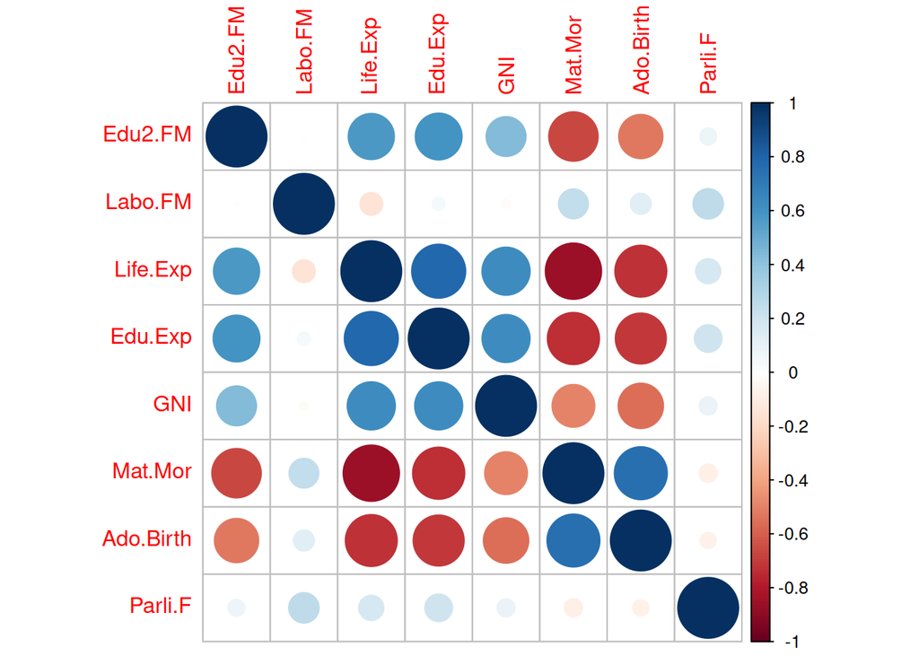

```r
# Access corrplot
library(corrplot)

# compute the correlation matrix and visualize it with corrplot
cor(human_) %>% corrplot()
```

## 5.6 PCA with R

[Principal Component Analysis](https://en.wikipedia.org/wiki/Principal_component_analysis) (PCA) can be performed by two sightly different matrix decomposition methods from linear algebra: the [Eigenvalue Decomposition](https://en.wikipedia.org/wiki/Eigendecomposition_of_a_matrix) and the [Singular Value Decomposition](https://en.wikipedia.org/wiki/Singular_value_decomposition) (SVD).

There are two functions in the default package distribution of R that can be used to perform PCA: `princomp()` and `prcomp()`. The `prcomp()` function uses the SVD and is the preferred, more numerically accurate method.

Both methods quite literally *decompose* a data matrix into a product of smaller matrices, which let’s us extract the underlying **principal components**. This makes it possible to approximate a lower dimensional representation of the data by choosing only a few principal components.

### Instructions

- Create `human_std` by standardizing the variables in `human`.
- Print out summaries of the standardized variables. What are the means? Do you know the standard deviations? (hint: `?scale`)
- Use `prcomp()` to perform principal component analysis on the standardized data. Save the results in the object `pca_human`
- Use `biplot()` to draw a biplot of `pca_human` (Click next to “Plots” to view it larger)
- Experiment with the argument `cex` of `biplot()`. It should be a vector of length 2 and it can be used to scale the labels in the biplot. Try for example `cex = c(0.8, 1)`. Which number affects what?
- Add the argument `col = c("grey40", "deeppink2")`

Hint: - Use the `summary()` function to compute summaries of the variables in a data frame

### R code

```r
# Work with the exercise in this chunk, step-by-step. Fix the R code!
# modified human is available

# standardize the variables
human_std <- scale(human)

# print out summaries of the standardized variables
summary(human_std)
```

```
##     Edu2.FM           Labo.FM           Life.Exp          Edu.Exp
##  Min.   :-2.8189   Min.   :-2.6247   Min.   :-2.7188   Min.   :-2.7378
##  1st Qu.:-0.5233   1st Qu.:-0.5484   1st Qu.:-0.6425   1st Qu.:-0.6782
##  Median : 0.3503   Median : 0.2316   Median : 0.3056   Median : 0.1140
##  Mean   : 0.0000   Mean   : 0.0000   Mean   : 0.0000   Mean   : 0.0000
##  3rd Qu.: 0.5958   3rd Qu.: 0.7350   3rd Qu.: 0.6717   3rd Qu.: 0.7126
##  Max.   : 2.6646   Max.   : 1.6632   Max.   : 1.4218   Max.   : 2.4730
##       GNI             Mat.Mor          Ado.Birth          Parli.F
##  Min.   :-0.9193   Min.   :-0.6992   Min.   :-1.1325   Min.   :-1.8203
##  1st Qu.:-0.7243   1st Qu.:-0.6496   1st Qu.:-0.8394   1st Qu.:-0.7409
##  Median :-0.3013   Median :-0.4726   Median :-0.3298   Median :-0.1403
##  Mean   : 0.0000   Mean   : 0.0000   Mean   : 0.0000   Mean   : 0.0000
##  3rd Qu.: 0.3712   3rd Qu.: 0.1932   3rd Qu.: 0.6030   3rd Qu.: 0.6127
##  Max.   : 5.6890   Max.   : 4.4899   Max.   : 3.8344   Max.   : 3.1850
```

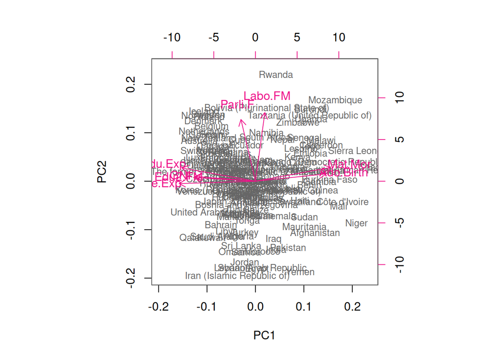

```r
# perform principal component analysis (with the SVD method)
pca_human <- prcomp(human_std)

# draw a biplot of the principal component representation and the original variables
biplot(pca_human, choices = 1:2, cex = c(0.8,1), col = c("grey40", "deeppink2"))
```

## 5.7 A biplot of PCA

A biplot is a way of visualizing the connections between two representations of the same data. First, a simple scatter plot is drawn where the observations are represented by two principal components (PC’s). Then, arrows are drawn to visualize the connections between the original variables and the PC’s. The following connections hold:

- The angle between the arrows can be interpreted as the correlation between the variables.
- The angle between a variable and a PC axis can be interpreted as the correlation between the two.
- The length of the arrows are proportional to the standard deviations of the variables.

### Instructions

- Create and print out a summary of `pca_human` (created in the previous exercise)
- Create object `pca_pr` and print it out
- Adjust the code: instead of proportions of variance, save the percentages of variance in the `pca_pr` object. Round the percentages to 1 digit.
- Execute the `paste0()` function. Then create a new object `pc_lab` by assigning the output to it.
- Draw the biplot again. Use the first value of the `pc_lab` vector as the label for the x-axis and the second value as the label for the y-axis.

Hints: - Percentages are proportions on a different scale. Multiplication by 100 changes proportions to percentages. - Objects are created with the assign operator `<-` - Brackets can be used to access values of a vector: `V[1]` gets the first value of `V`

### R code

```r
# Work with the exercise in this chunk, step-by-step. Fix the R code!
# pca_human, dplyr are available

# create and print out a summary of pca_human
s <- summary(pca_human)

# rounded percentanges of variance captured by each PC
pca_pr <- round(100*s$importance[2, ], digits = 1)

# print out the percentages of variance
pca_pr
```

```
##  PC1  PC2  PC3  PC4  PC5  PC6  PC7  PC8
## 53.6 16.2  9.6  7.6  5.5  3.6  2.6  1.3
```

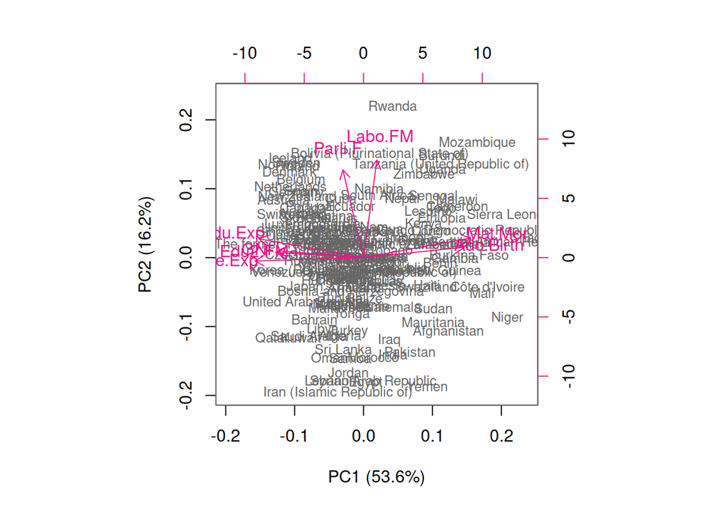

```r
# create object pc_lab to be used as axis labels
pc_lab <- paste0(names(pca_pr), " (", pca_pr, "%)")

# draw a biplot
biplot(pca_human, cex = c(0.8, 1), col = c("grey40", "deeppink2"), xlab = pc_lab[1], ylab = pc_lab[2])
```

## 5.8 It’s tea time!

The [Factominer](https://cran.r-project.org/web/packages/FactoMineR/index.html) package contains functions dedicated to multivariate explanatory data analysis. It contains for example methods *(Multiple) Correspondence analysis* , *Multiple Factor analysis* as well as PCA.

In the next exercises we are going to use the `tea` dataset. The dataset contains the answers of a questionnaire on tea consumption.

Let’s dwell in teas for a bit!

### Instructions

- Create the `keep_columns` object. Then `select()` the columns from `tea` to create a new dataset. Save the new data as `tea_time`.
- Look at the summaries and structure of the `tea_time` data.
- Visualize the dataset. Define the plot type by adding `geom_bar()` after initialization of the ggplot.
- Adjust the code: the labels of the x-axis are showing poorly. Make the plot more readable by adding `theme(axis.text.x = element_text(angle = 45, hjust = 1, size = 8))` after barplot code.

Hints: - `str()` and `summary()`. - Use the `+` mark to add functions to `ggplot()`

### R code

```r
# Work with the exercise in this chunk, step-by-step. Fix the R code!
# the tea dataset is available

library(dplyr)
library(tidyr)
# column names to keep in the dataset
keep_columns <- c("Tea", "How", "how", "sugar", "where", "lunch")

# select the 'keep_columns' to create a new dataset
tea_time <- select(tea, any_of(keep_columns))

# look at the summaries and structure of the data
tea_time
```

```
##           Tea   How                how    sugar                where     lunch
## 1       black alone            tea bag    sugar          chain store Not.lunch
## 2       black  milk            tea bag No.sugar          chain store Not.lunch
## 3   Earl Grey alone            tea bag No.sugar          chain store Not.lunch
## 4   Earl Grey alone            tea bag    sugar          chain store Not.lunch
## 5   Earl Grey alone            tea bag No.sugar          chain store Not.lunch
## 6   Earl Grey alone            tea bag No.sugar          chain store Not.lunch
## 7   Earl Grey alone            tea bag No.sugar          chain store Not.lunch
## 8       black  milk            tea bag No.sugar          chain store Not.lunch
## 9   Earl Grey  milk tea bag+unpackaged No.sugar chain store+tea shop Not.lunch
## 10      black alone tea bag+unpackaged No.sugar chain store+tea shop Not.lunch
## 11  Earl Grey alone            tea bag No.sugar          chain store Not.lunch
## 12  Earl Grey alone            tea bag    sugar          chain store Not.lunch
## 13  Earl Grey  milk tea bag+unpackaged No.sugar chain store+tea shop Not.lunch
## 14      black  milk            tea bag    sugar          chain store Not.lunch
```

[output cut: 286 more lines]

```r
summary(tea_time)
```

```
##         Tea         How                      how           sugar
##  black    : 74   alone:195   tea bag           :170   No.sugar:155
##  Earl Grey:193   lemon: 33   tea bag+unpackaged: 94   sugar   :145
##  green    : 33   milk : 63   unpackaged        : 36
##                  other:  9
##                   where           lunch
##  chain store         :192   lunch    : 44
##  chain store+tea shop: 78   Not.lunch:256
##  tea shop            : 30
##
```

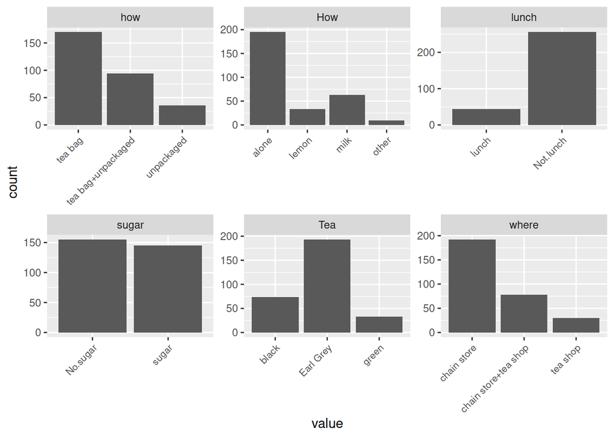

```r
# visualize the dataset
library(ggplot2)
pivot_longer(tea_time, cols = everything()) %>%
  ggplot(aes(value)) + geom_bar() + facet_wrap("name", scales = "free") + theme(axis.text.x = element_text(angle = 45, hjust = 1, size = 8))
```

## 5.9 Multiple Correspondence Analysis

[Multiple Correspondence Analysis](https://en.wikipedia.org/wiki/Multiple_correspondence_analysis) (MCA) is a method to analyze qualitative data and it is an extension of Correspondence analysis (CA). MCA can be used to detect patterns or structure in the data as well as in dimension reduction.

**Note:** You should first install the package `FactoMineR`.

### Instructions

- Do multiple correspondence analysis with the function `MCA()`. Give `tea_time` as the functions first argument. Note that the `MCA()` function visualizes the analysis by default, and the plots can be turned off with the argument `graph = FALSE`.
- Look at the summary of the model.
- Plot the variables of the model. You can either plot the variables or the individuals or both. You can change which one to plot with the `invisible` argument.
- Adjust the code: add argument `habillage = "quali"` (how French!) to the plot. Do you notice what changes?

Hint: - See the FactoMineR [documentation](https://cran.r-project.org/web/packages/FactoMineR/FactoMineR.pdf) for help

### R code

```r
# Work with the exercise in this chunk, step-by-step. Fix the R code!
# tea_time is available

# multiple correspondence analysis
library(FactoMineR)
mca <- MCA(tea_time, graph = FALSE)

# summary of the model
summary(mca)
```

```
##
## Call:
## MCA(X = tea_time, graph = FALSE)
##
##
## Eigenvalues
##                        Dim.1   Dim.2   Dim.3   Dim.4   Dim.5   Dim.6   Dim.7
## Variance               0.279   0.261   0.219   0.189   0.177   0.156   0.144
## % of var.             15.238  14.232  11.964  10.333   9.667   8.519   7.841
## Cumulative % of var.  15.238  29.471  41.435  51.768  61.434  69.953  77.794
##                        Dim.8   Dim.9  Dim.10  Dim.11
## Variance               0.141   0.117   0.087   0.062
## % of var.              7.705   6.392   4.724   3.385
## Cumulative % of var.  85.500  91.891  96.615 100.000
##
## Individuals (the 10 first)
##                       Dim.1    ctr   cos2    Dim.2    ctr   cos2    Dim.3
## 1                  | -0.298  0.106  0.086 | -0.328  0.137  0.105 | -0.327
## 2                  | -0.237  0.067  0.036 | -0.136  0.024  0.012 | -0.695
## 3                  | -0.369  0.162  0.231 | -0.300  0.115  0.153 | -0.202
## 4                  | -0.530  0.335  0.460 | -0.318  0.129  0.166 |  0.211
## 5                  | -0.369  0.162  0.231 | -0.300  0.115  0.153 | -0.202
## 6                  | -0.369  0.162  0.231 | -0.300  0.115  0.153 | -0.202
## 7                  | -0.369  0.162  0.231 | -0.300  0.115  0.153 | -0.202
## 8                  | -0.237  0.067  0.036 | -0.136  0.024  0.012 | -0.695
## 9                  |  0.143  0.024  0.012 |  0.871  0.969  0.435 | -0.067
## 10                 |  0.476  0.271  0.140 |  0.687  0.604  0.291 | -0.650
##                       ctr   cos2
## 1                   0.163  0.104 |
## 2                   0.735  0.314 |
## 3                   0.062  0.069 |
## 4                   0.068  0.073 |
## 5                   0.062  0.069 |
## 6                   0.062  0.069 |
## 7                   0.062  0.069 |
## 8                   0.735  0.314 |
## 9                   0.007  0.003 |
## 10                  0.643  0.261 |
##
## Categories (the 10 first)
```

[output cut: 16 more lines]

```
## lemon                3.226 |   1.329  14.771   0.218   8.081 |
## milk                 2.422 |   0.013   0.003   0.000   0.116 |
## other                5.534 |  -2.524  14.526   0.197  -7.676 |
## tea bag             -6.941 |  -0.065   0.183   0.006  -1.287 |
## tea bag+unpackaged  11.956 |   0.019   0.009   0.000   0.226 |
## unpackaged          -6.482 |   0.257   0.602   0.009   1.640 |
##
## Categorical variables (eta2)
##                      Dim.1 Dim.2 Dim.3
## Tea                | 0.126 0.108 0.410 |
## How                | 0.076 0.190 0.394 |
## how                | 0.708 0.522 0.010 |
## sugar              | 0.065 0.001 0.336 |
## where              | 0.702 0.681 0.055 |
## lunch              | 0.000 0.064 0.111 |
```

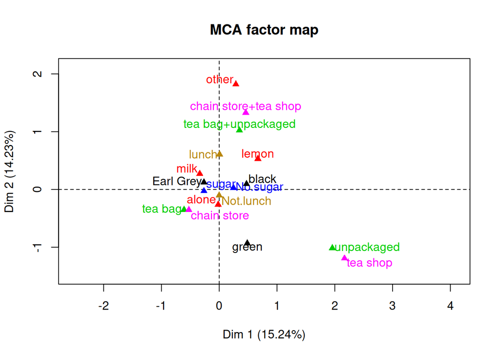

```r
# visualize MCA
plot(mca, invisible=c("ind"), graph.type = "classic", habillage = "quali")
```

**Great work!!**